# STAT 531 Portfolio

## Data Simulation & Statistical Models

**DSSM-1: I can simulate data from a *variety* of probability models.**

- Example 1

```r
# Lab 10 Question 4

x = runif(100, min = 0, max = 1)
```

- Example 2

```r
# Lab 10 Question 4

ep = rnorm(100, mean = 0, sd = 1)
```

**DSSM-2: I can conduct common statistical analyses in R.**

- Example 1

```r
# Lab 3 Question 3

chisq.test(x = teacher_evals_compare$sen_level, y = teacher_evals_compare$SET_level)
```

- Example 2

```r
# Lab 4 Question 9

reg_mod1 <- lm(ca_childcare$mc_infant ~ ca_childcare$mhi_2018)
summary(reg_mod1)
```

- Example 3

```r
# Lab 1

t.test(len ~ supp, data = ToothGrowth, var.equal = FALSE)
```

## Revising My Thinking

I’ve revised my thinking several times throughout the course by taking feedback to make code more efficient or improve readability in my plots and tables. For over half of my submissions, I have resubmitted assignments where many skills were growing. There are examples here where code has been modified from my original submission (and some which has been modified expressly for use in the portfolio, denoted with comments throughout).

Noted in assignment body.

## Extending My Thinking

I’ve often extended my thinking in this course by applying previously-learned techniques in new ways. I think this is particularly true of my approach to data visualization in challenge 4. For the open-ended analysis, I opted to use HTML editing tools learned in week 2 to add some color directly to the text of my plots - improving readability on what would otherwise be a busy visual. In much of my code, I’ve made an effort to be creative and think about usability in my code (e.g. considering resilience to inputs when writing functions + implementing stop functions and messages, thinking of creative ways to present data in tables and plots).

## Peer Support & Collaboration

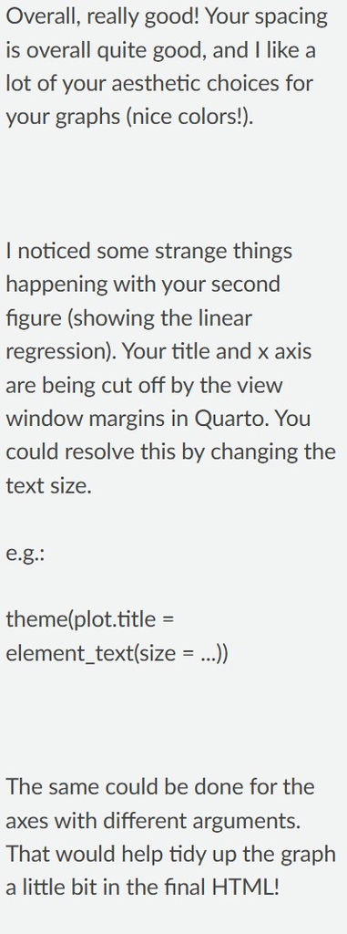

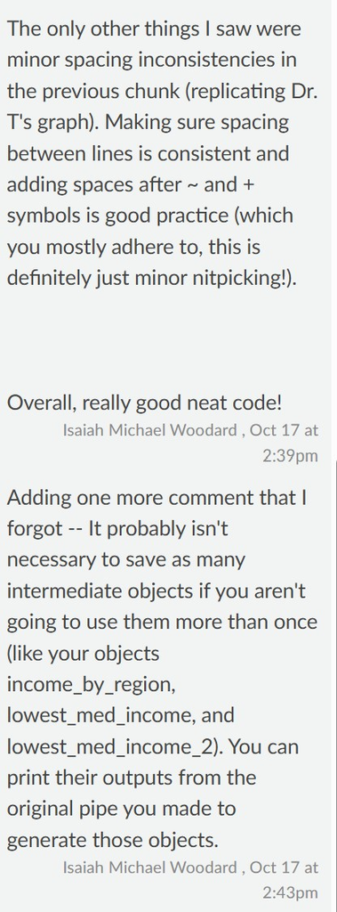

I think when I first started doing the pair programming activities, I stuck to my assigned role well, but didn’t really know how to support my coding partner if we hit a snag (without telling them a solution I thought of directly). I think I’ve gotten better at prompting helpful next steps/ resources without centering my own ideas (e.g. saying this reminds me of an example we saw earlier, prompting them to look at the handouts, etc.). I’ve picked up those habits in part by observing how others have helped me when I hit snags, without making me feel like they were taking over my role.